# QSGA Whitepaper 6 - Applications and ROP Laplacians Hamiltonian Simulation

Ohad Lev

December 2025

## Glossary

- QSGA = Quantum Spectral Graph Analysis.
- ROP = Random Order perturbed

## Imports

```python
from qiskit import transpile
from qiskit.quantum_info import SparsePauliOp
from qiskit.circuit.library import PauliEvolutionGate
from qiskit.synthesis import SuzukiTrotter
```

## Introduction

In this whitepaper I address the applicability of our proposed QSGA method.

We have already formalized a compact Hamiltonian representation of non-trivial exponentially-large graphs, specifically ROP Laplacians. **What can we do it?**

This issue can be addressed quite broadly, but I am going to focus here on Hamiltonian simulation, for several reasons:

- Performing Hamiltonian simulation on a quantum computer is exponentially more efficient than the classical alternative, for some classes of (finite dimensional and time-independent) Hamiltonians.
  - It was first shown by Lloyd **[Llo96]** for $k$-local Hamiltonians.
  - Later on, a generalization for $d$-sparse Hamiltonians was given **[AT03]**, under several assumptions.
  - In the $3$ decades of research since then, many additional Hamiltonian simulation techniques and algorithms were derived **[Dal+25]**.
- The Hamiltonian simulation routine is considered as the natural computer for a quantum computer to do. The inception of the quantum computation field is rooted in Feynman's belief, among others, that a "quantum mechanical machine" will be able to simulate nature (= Hamiltonians) efficiently **[Fey82]**. Hamiltonians can be or constructed either simple & easy or complex & hard. Correspondingly, Hamiltonian simulation of "easy-enough" (but still classically-intractable) Hamiltonians is sometimes considered as the first real application that would work on early fault-tolerant quantum computers, or even without error correction, assuming future systems' advances **[Chi+18]**.
- Hamiltonian simulation is used as the main quantum subroutine in quantum Krylov diagonalization algorithms **[ELY22, Yos+25]**. It can be of great use to our purpose, since we are interested in computing eigenvalues of graph matrices, e.g. $\lambda_2$ of the graph Laplacian. Quantum Krylov diagonalization algorithms might allow to compute low/high order eigenvalues of exponentially large Hamiltonian matrices.

## Hamiltonian Simulation - Definition

In simple words, for finite-dimensional and time-independent Hamiltonians, the quantum Hamiltonian simulation problem can be phrased as:

**Given a Hamiltonian $H$, approximately implement the unitary operator $U = e^{-iHt}$ efficiently**

## Hamiltonian Simulation Algorithms

I find the historic evolution and taxonomy of quantum Hamiltonian simulation algorithms quite complex and non-organized. Even more surprising is that I couldn't find a decent and recent review that summarizes this issue. The closest thing I found to such a review is Chapter 11 in the book - *Quantum Algorithms: A Survey of Applications and End-to-End Complexities* **[Dal+25]**. A useful taxonomy table from this resource is brought below.

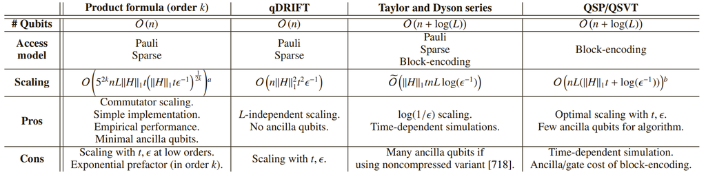

Table 11.1 from **[Dal+25]**

The original Hamiltonian simulation techinque introduced in **[Llo96]** is based on "first-order Trotterization", also called the "Lie-Trotter technique". It is well suited for the case when the Hamiltonians is or can be expressed as a sum of $k$-local operators. It works as follows.

### Lie-Trotter (= First Order) Approximated Evolution

It is well known that a unitary evolution for a time span $t$, can be generated from any Hermitian operator Hamiltonian $H$:

$$ U = e^{-iHt} \tag{1} $$

Also, let:

$$ H = \sum_{j = 1}^{L} H_j \tag{2} $$

be a decomposition/construction of the Hamiltonians into $L$ individual $H_j$ Hamiltonian terms. Then:

$$ U = e^{-iHt} = e^{-it \sum_{j=1}^L H_j} \tag{3} $$

It is tempting to transform the sum in the exponent into a prduct of exponents, but it is possible only if all the $H_j$ terms mutually commute. What we can do, in the general case, is to use this transform as an approximation. Lloyd **[Llo96]** showed that that Trotterization is helpful to approximately simulate & suppress the errors arising from the noncommutativity:

$$ U = \bigg( \prod_{j=1}^{L} e^{-iH_j t / r} \bigg)^r + \underbrace{\sum_{i > j} \big[H_i, H_j \big] \frac{t^2}{2r}}_{2\text{nd Order Commutation Error}} + \underbrace{\sum_{k = 3}^{\infty} E(k)}_{\text{Higher Order Errors}} \tag{4} $$

Where:

- $t$ is the overall desired simulation time.
- $r$ is the number of steps we decide to divide the simulation into ("Trotterization").
- The second order commutation error dominates the overall approximation error. It is suppressed by $r$ - for a fixed $t$, make $r$ large enough, and the error will decay.
  - There is tradeoff here with circuit depth. $r$ grows $\implies$ circuit depth grows $\implies$ decoherence and other noise sources kick in. It can be overcomed with error correction.
- The higher order errors are shown to be negligible, we will not dive into that in the scope of this whitepaper.

Example for:

$$ \begin{cases} n = 5 \\ H = 0.6XXXIX + 0.8XXIII \\ r = 2 \end{cases} \tag{5} $$

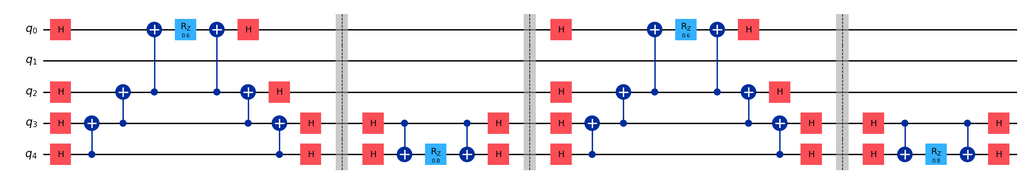

```python
H = SparsePauliOp(["XXXIX", "XXIII"], [0.6, 0.8])
peg = PauliEvolutionGate(operator=H)

trotterization_gen = SuzukiTrotter(order=1, reps=2, insert_barriers=True)
qc = trotterization_gen.synthesize(peg)

tpqc = transpile(qc, basis_gates=["h", "rz", "cx"])
tpqc.draw("mpl", fold=-1)
```

### Suzuki-Trotter (= Higher Order) Approximated Evolution

Higher-order Trotterization allows for better suppression of the Trotter error (E.g. $\propto t^3 / r^2$ for second order), in the price of deeper circuit implementation (second order example for the same configuration):

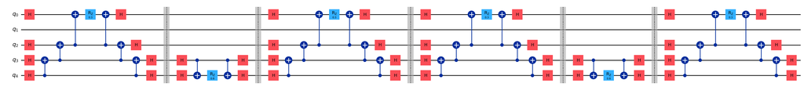

```python
trotterization_gen = SuzukiTrotter(order=2, reps=2, insert_barriers=True)
qc = trotterization_gen.synthesize(peg)

tpqc = transpile(qc, basis_gates=["h", "rz", "cx"])
tpqc.draw("mpl", fold=-1)
```

### Simulating Sparse Hamiltonians

Nevertheless, it was shown in **[AT03]** that given a black-box that returns the $(i, j)$ entry of the Hamiltonian matrix in constant time, also $d$-sparse Hamltonians are efficiently simulable. This approach was later greatly developed by Childs, Kothari and others. I wonder what is the use case for such an approach - what is the real-life situation of having such a black box where classical approaches are non-applicable with ease?

It seems that indeed this approach is applicable and not purely theoretic. For example, the `SuzukiTrotter` Qiskti implementation above is based on **[Ber+07]**. Need to further look into that TODO.

### Others

It seems that the state-of-the-art the art technique for Hamiltonian simulation is a method called "Qubitization" **[LC19]**, which is based on a quantum signal processing approach. But I am not sure if it is well suited for our case.

## Applicability for QSGA

When I first thought about QSGA, I was inspired from the approaches abundant in simulaiton of Hamiltonians form condensed matter physics, which seems to be based on product-formulas, a.k.a some variants of the original Trotterization introduced by Lloyd.

I am wondering if the other approaches are applicable and if we should dive into this ocean.

What we do need at least for the first paper, is to set bounds/orders for the following:

- The locality of the skeleton Laplacian $l_s$.
- The locality of the perturbation $l_p$.
- The number of perturbations $n_p$.
- The regularity of the skeleton graph $d$.

From a purely product-formulas approach, it seems that we should define:

$$ l_s \sim O(1) \\ l_p \sim O(1) \\ n_p \sim O(\mathrm{poly}(n)) \\ d \sim O(\mathrm{poly}(n)) \\ $$

We need to describe the influence of noncommutativity of Hamiltonian terms.

Can we employ the $d$-sparse Hamiltonian simulaiton approach to derive stronger scalings/bounds?

## References

**[AT23]** Aharonov, Dorit, and Amnon Ta-Shma. "**Adiabatic quantum state generation and statistical zero knowledge.**" [Proceedings of the thirty-fifth annual ACM symposium on Theory of computing. 2003](https://dl.acm.org/doi/abs/10.1145/780542.780546).

**[Ber+07]** Berry, Dominic W., et al. "**Efficient quantum algorithms for simulating sparse Hamiltonians.**" [Communications in Mathematical Physics 270.2 (2007): 359-371](https://link.springer.com/article/10.1007/s00220-006-0150-x).

**[Chi+18]** Childs, Andrew M., et al. "**Toward the first quantum simulation with quantum speedup.**" [Proceedings of the National Academy of Sciences 115.38 (2018): 9456-9461](https://www.pnas.org/doi/abs/10.1073/pnas.1801723115).

**[Dal+25]** Dalzell AM, McArdle S, Berta M, et al. "**Quantum Algorithms: A Survey of Applications and End-to-End Complexities.**" [Cambridge University Press; 2025](https://www.cambridge.org/core/books/quantum-algorithms/EF7A52B88199BC0DA5A2CC99794A8C39). [Chapter 11 - Hamiltonian Simulation](https://www-cambridge-org.accedys.udc.es/core/books/quantum-algorithms/hamiltonian-simulation/94D3D7A8C829393E75EEC4A6678DB62A).

**[ELY22]** Epperly, Ethan N., Lin Lin, and Yuji Nakatsukasa. "**A theory of quantum subspace diagonalization.**" SIAM Journal on Matrix Analysis and Applications [43.3 (2022): 1263-1290](https://epubs.siam.org/doi/10.1137/21M145954X).

**[Fey82]** Feynman, Richard P. “**Simulating physics with computers.**” [International Journal of Theoretical Physics 21, no. 6–7 (1982): 467–488](https://link.springer.com/article/10.1007/BF02650179).

**[LC19]** Low, Guang Hao, and Isaac L. Chuang. "**Hamiltonian simulation by qubitization.**" [Quantum 3 (2019): 163](https://quantum-journal.org/papers/q-2019-07-12-163/).

**[Llo96]** Lloyd, Seth. "**Universal quantum simulators.**" [Science 273.5278 (1996): 1073-1078](https://www.science.org/doi/abs/10.1126/science.273.5278.1073).

**[Yos+25]** Yoshioka, Nobuyuki, et al. "**Krylov diagonalization of large many-body Hamiltonians on a quantum processor.**" [Nature Communications 16.1 (2025): 5014](https://www.nature.com/articles/s41467-025-59716-z).

## DRAFTS

Let a Hamiltonian $H$ have a decomposition into $L$ terms:

$$ H = \sum_{j = 1}^{L} H_j \tag{1} $$

Then the corresponding first-order product formula is:

$$ U_1(t) = \bigg( \prod_{j = 1}^{L} e^{i H_j \frac{t}{r}} \bigg)^r \tag{2} $$

Where $r$ is the number of "Trotter" steps, and $t$ is a time-step of choose.

Why?

1. We know that given a finite-dimensional & time-independent Hamiltonian $H$, then its unitary evolution is defined by $U = e^{iHt}$, assuming $\hbar = 1$ convention.
2. The Hamiltonian $H$ has a complete matrix representation by definition (finite-dimensional), but we are more interested in its decomposition/construction from simple terms (**Equation (1)**), since it is much more practical to derive unitaries that way. So: $$ e^{iHt} = e^{i \sum_j H_j t} = \prod_j e^{i H_j t} + O(t^2) \tag{3} $$ Unless all $H_j$ terms commute (the error free case), then an error on the order of $t^2$ is introduced.
3. The division to $r$ "Trotter" steps now makes sense, since the "Trotter error" term $O(t^2)$ vanishes as $t$ gets smaller and approaches $0$. So instead of letting the simulation evolve for the desired simulation time, the solution to surpress such Trotter errors is to divide the simulation into $r$ small simulation steps, each of time $t / r$, as seen in **Equation (2)**.

In the simple and rare case where all the $H_j$ terms commute, by simple exponents algebra we can write:

$$ U_{\text{C}} = \prod_{j = 1}^{L} e^{-iH_jt} \tag{4} $$

However, in the general case the terms $H_j$ do not commute, hence an error $\varepsilon$ is introduced into the synthesis of the non-commutative case:

$$ U_{\text{NC}} = U_C + \varepsilon \tag{5} $$

In this notebook we will not dive deep into theory, however what Lloyd showed in **[Llo96]**, based on previous discoveries of others, is that this error can be supressed by dividing the evolution into $r$ small time steps:

$$ U \approx \bigg( \prod_{j=1}^{L} e^{-iH_j \Delta t} \bigg)^r, \quad \quad \mathrm{s.t:} \quad \Delta t = \frac{t}{r} \tag{6} $$